# R Markdown Assignment

### Importing Packages

We begin by importing the “dplyr” package

```r
#install.packages("dplyr")
library("dplyr")
```

### Data Pre-processing

The only pre-processing we are going to perform after loading is just dropping all rows with an “NA” value in them.

```r
act_data_original <- read.csv("activity.csv")
act_data <- na.omit(act_data_original)
```

### Total Number of Steps Taken per Day

We will find the steps taken every day by selecting only the date and steps columns, grouping them by date, and then adding a new column with the sum of steps for each day. With this dataframe we can then plot the results, determine the mean daily step count, and determine the median daily step count. With these results we will depict them as a histogram and we will print out the mean and median numbers of steps taken per day

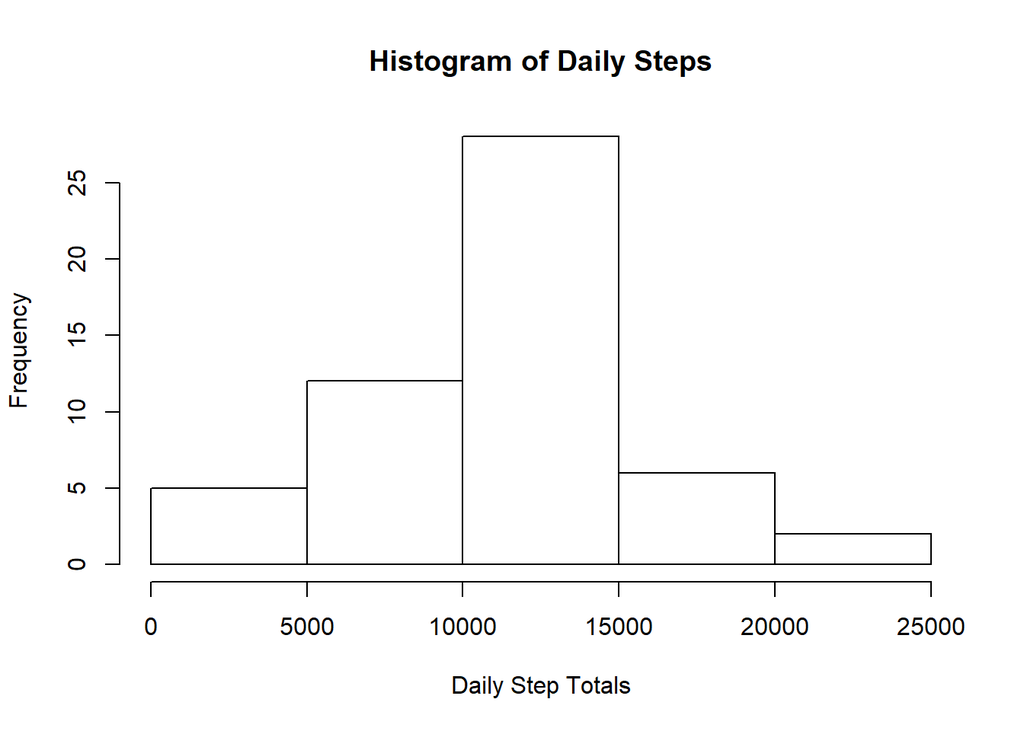

```r
## Get sum of steps per day
daily_steps <- act_data %>% select(date, steps) %>% group_by(date) %>% summarise(daily_step_total = sum(steps))
## Calculate mean and median for frame
mean_daily_step_total <- mean(daily_steps$daily_step_total)
median_daily_step_total <- median(daily_steps$daily_step_total)
hist(daily_steps$daily_step_total,main = "Histogram of Daily Steps",xlab = "Daily Step Totals")
```

```r
cat("Mean daily step count: ",mean_daily_step_total,"\n")
```

```
## Mean daily step count:  10766.19
```

```r
cat("Median daily step count: ",median_daily_step_total)
```

```
## Median daily step count:  10765
```

### Average Daily Activity Pattern

In this section we will look across all of our days of data for the average number of steps taken for each 5 minute interval. We will take a similar approach as we took when finding the total number of steps per day, but we will group by interval instead of day. Additionally, we will use the mean function in our summarize statement instead of the sum function. We will display the results as a line plot and we will print out the interval with the highest average steps.

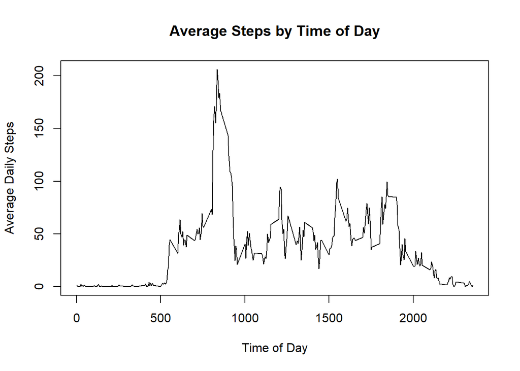

```r
## Get sum of steps by 5 minute interval
tod_steps <- act_data %>% select(interval, steps) %>% group_by(interval) %>% summarise(average_step_total = mean(steps))
mean_tod_steps <- mean(tod_steps$average_step_total)
## Display as time series plot
plot(tod_steps,type="l", main = "Average Steps by Time of Day", xlab = "Time of Day", ylab="Average Daily Steps")
```

```r
cat("Interval with highest average steps: ", tod_steps$interval[which.max(tod_steps$average_step_total)])
```

```
## Interval with highest average steps:  835
```

### Imputing Missing Values

Just taking a simple approach to imputing missing values. Replacing missing values with the interval average of the per interval steps averaged across all days.

```r
## Report and replace the na values
num_na <- sum(is.na(act_data_original$steps))
cat("There are ", num_na," missing values in the dataset.\n")
```

```
## There are  2304  missing values in the dataset.
```

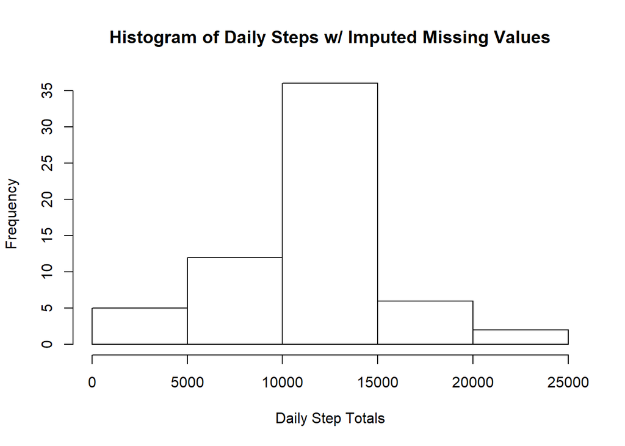

```r
imp_act_data <- act_data_original %>% mutate(steps_new = ifelse(is.na(act_data_original$steps), mean_tod_steps, act_data_original$steps)) %>% select(steps_new, date, interval)

## Get sum of steps per day
daily_steps_imp <- imp_act_data %>% select(date, steps_new) %>% group_by(date) %>% summarise(daily_step_total = sum(steps_new))
## Calculate mean and median for frame
mean_daily_step_total_imp <- mean(daily_steps_imp$daily_step_total)
median_daily_step_total_imp <- median(daily_steps_imp$daily_step_total)
hist(daily_steps_imp$daily_step_total,main = "Histogram of Daily Steps w/ Imputed Missing Values",xlab = "Daily Step Totals")
```

```r
cat("Mean daily step count with imputed missing values: ",mean_daily_step_total_imp,"\n")
```

```
## Mean daily step count with imputed missing values:  10766.19
```

```r
cat("Median daily step count with imputed missing values: ",median_daily_step_total_imp)
```

```
## Median daily step count with imputed missing values:  10766.19
```

The mean and median with this imputed dataset now match the mean value from the data where “NA” values were dropped. Imputing the values the way we did adds many values which are at the mean of the rest of the data, lowering the standard deviation of the dataset.

### Differences in Weekend and Weekday Activity

[figure not shown]

```r
## Start off by making lists for weekdays and weekends
weekday_list <- c("Monday", "Tuesday", "Wednesday", "Thursday")
## Use 'mutate' to add new columns denoting weekends or weekdays
imp_act_data <- imp_act_data %>%
  mutate(dow = weekdays(as.Date(imp_act_data$date, format="%Y-%m-%d"))) %>%
  mutate(weekday = ifelse(dow %in% weekday_list, "weekday", "weekend"))
## Depict results in a graphic
weekday_tod_steps <- imp_act_data %>% select(interval, steps_new, weekday) %>% filter(weekday == "weekday") %>%
  group_by(interval) %>% summarise(average_step_total = mean(steps_new))
weekend_tod_steps <- imp_act_data %>% select(interval, steps_new, weekday) %>% filter(weekday == "weekend") %>%
  group_by(interval) %>% summarise(average_step_total = mean(steps_new))
par(mfrow=c(2,1))
plot(weekday_tod_steps,type="l", main = "Weekday Average Steps by Time of Day", xlab = "Time of Day", ylab="Average Daily Steps")
plot(weekend_tod_steps,type="l", main = "Weekend Average Steps by Time of Day", xlab = "Time of Day", ylab="Average Daily Steps")
```